# 04. Organize Data

### Verbs

In these notes we are going to cover a set of functions that take a data frame as an input and return a new version of the data frame. These functions are called *verbs* and come from the **dplyr** package. If you are familiar with running database queries, note that all of these verbs map onto SQL commands. In fact, R can be set up so that **dplyr** is called over a database rather than a local data frame in memory.

There are over 40 verbs in the **dplyr** package, though most are a minor variant or specific application of another verb. In this notebook we will see only four of them:

- select a subset of rows from the original data set (`filter` and `slice`)
- select a subset of columns from the original data set (`select`)
- sort the rows of a data set (`arrange`)

In all verb functions, the first argument is the original data frame and the output is a new data frame. Here, we will also see the functions `between` and `%in%` to assist with the filtering command and `desc` to assist with arranging the rows of a data set.

Note that **verbs do not modify the original data**; they operate on a copy of the original data. We have to make an explicit name for the new data set if we want to save it for use elsewhere.

## Choosing rows

It is often useful to take a subset of the rows of an existing data set, for example if you want to build a model on a certain subpopulation or highlight a particular part of the data in a plot. Perhaps the most straightforward way to take a subset of rows is to indicate the specific row numbers that we want to extract. In order to select rows by row numbers, we use the verb `slice`, followed by the numbers of the rows we want separated by commas. Here is an example taking the second, fifth, and seventh rows of the data:

```r
food |>
  slice(2, 5, 7)
```

```
## # A tibble: 3 × 17
##   item  food_group calories total_fat sat_fat cholesterol sodium carbs fiber
##   <chr> <chr>         <dbl>     <dbl>   <dbl>       <dbl>  <dbl> <dbl> <dbl>
## 1 Aspa… vegetable        20       0.1   0.046           0      2  3.88   2.1
## 2 Chic… grains          180       2.9   0.309           0    243 30.0    8.6
## 3 Beef  meat            288      19.5   7.73           87    384  0      0
## # ℹ 8 more variables: sugar <dbl>, protein <dbl>, iron <dbl>,
## #   vitamin_a <dbl>, vitamin_c <dbl>, wiki <chr>, description <chr>,
## #   color <chr>
```

As mentioned above, the code here does not change the data set `food` itself. It still has all 61 rows of food contained in it. If we want to create a new data set with just these three food item, we need to explicitly name and assign it. For example, here is how we would create a data set of the first five food items named `food_first_five`:

```r
food_first_five <- food |>
  slice(1, 2, 3, 4, 5)
```

There is a convenient a shorthand for selecting a range of row numbers, for example every row from the tenth to the twentieth, by indicating the starting and ending row number by a colon. Here, for example, is another way to select the first five rows of the data set:

```r
food |>
  slice(1:5)
```

```
## # A tibble: 5 × 17
##   item  food_group calories total_fat sat_fat cholesterol sodium carbs fiber
##   <chr> <chr>         <dbl>     <dbl>   <dbl>       <dbl>  <dbl> <dbl> <dbl>
## 1 Apple fruit            52       0.1   0.028           0      1 13.8    2.4
## 2 Aspa… vegetable        20       0.1   0.046           0      2  3.88   2.1
## 3 Avoc… fruit           160      14.6   2.13            0      7  8.53   6.7
## 4 Bana… fruit            89       0.3   0.112           0      1 22.8    2.6
## 5 Chic… grains          180       2.9   0.309           0    243 30.0    8.6
## # ℹ 8 more variables: sugar <dbl>, protein <dbl>, iron <dbl>,
## #   vitamin_a <dbl>, vitamin_c <dbl>, wiki <chr>, description <chr>,
## #   color <chr>
```

Another way to take a subset of our data is to select rows based on conditions about the features in the data set. To do this we use the `filter` function, which accepts a statement about features in the data set. Only rows where the statements are true will be returned. For example, here is how we use the `filter` command to select the foods that have more than 150 calories grams of sugar in each serving:

```r
food |>
  filter(calories > 150)
```

```
## # A tibble: 20 × 17
##    item       food_group calories total_fat sat_fat cholesterol sodium carbs
##    <chr>      <chr>         <dbl>     <dbl>   <dbl>       <dbl>  <dbl> <dbl>
##  1 Avocado    fruit           160      14.6   2.13            0      7  8.53
##  2 Chickpea   grains          180       2.9   0.309           0    243 30.0
##  3 Beef       meat            288      19.5   7.73           87    384  0
##  4 Catfish    fish            240      14.5   3.25           69    398  8.54
##  5 Cheese     dairy           350      26.9  16.6            83    955  4.71
##  6 Chicken    meat            237      13.4   3.76           87    404  0
##  7 Clam       fish            180       8     1.60           56    400 11.1
##  8 Cod        fish            211      10.8   2.22           57    401  8.25
##  9 Halibut    fish            239      17.7   3.10           59    103  0
## 10 Lamb       meat            292      20.7   8.76           96    394  0
## 11 Oat        grains          389       6     1.22            0      2 66.3
## 12 Oyster     fish            160       7.9   1.85           57    595 12.5
## 13 Penne      grains          157       0.9   0.175           0    233 30.7
## 14 Pork       meat            271      17     6.17           90    384  0
## 15 Salmon     fish            171       7.5   1.31           62    467  0.49
## 16 Scallop    fish            217      10.9   2.22           54    487 10.5
## 17 Sour Cream dairy           214      20.9  13.0            44     53  4.27
## 18 Swordfish  fish            177       8.2   1.96           47    494  0.49
## 19 Tuna       fish            153       3.9   0.811          53    366  0.41
## 20 Turkey     meat            187       7     2.00           77     69  0
## # ℹ 9 more variables: fiber <dbl>, sugar <dbl>, protein <dbl>, iron <dbl>,
## #   vitamin_a <dbl>, vitamin_c <dbl>, wiki <chr>, description <chr>,
## #   color <chr>
```

```r
food |>
  filter(between(total_fat, 2, 3))
```

```
## # A tibble: 4 × 17
##   item  food_group calories total_fat sat_fat cholesterol sodium carbs fiber
##   <chr> <chr>         <dbl>     <dbl>   <dbl>       <dbl>  <dbl> <dbl> <dbl>
## 1 Chic… grains          180       2.9   0.309           0    243 30.0    8.6
## 2 Quin… grains          143       2.2   0.226           0    196 26.4    2.3
## 3 Shri… fish            144       2.3   0.446         206    613  1.24   0
## 4 Pota… vegetable       104       2     0.458           0    254 19.4    1.7
## # ℹ 8 more variables: sugar <dbl>, protein <dbl>, iron <dbl>,
## #   vitamin_a <dbl>, vitamin_c <dbl>, wiki <chr>, description <chr>,
## #   color <chr>
```

If you want to filter on a categorical feature, you can use the `%in%` operator to select specific categories. Here is the code to filter only the fish and vegetable food groups:

```r
food |>
  filter(food_group %in% c("fish", "vegetable"))
```

```
## # A tibble: 30 × 17
##    item       food_group calories total_fat sat_fat cholesterol sodium carbs
##    <chr>      <chr>         <dbl>     <dbl>   <dbl>       <dbl>  <dbl> <dbl>
##  1 Asparagus  vegetable        20       0.1   0.046           0      2  3.88
##  2 String Be… vegetable        31       0.1   0.026           0      6  7.13
##  3 Bell Pepp… vegetable        26       0     0.059           0      2  6.03
##  4 Crab       fish             87       1     0.222          78    293  0.04
##  5 Broccoli   vegetable        34       0.3   0.039           0     33  6.64
##  6 Cabbage    vegetable        24       0.1   0.016           0     18  5.58
##  7 Carrot     vegetable        41       0.2   0.037           0     69  9.58
##  8 Catfish    fish            240      14.5   3.25           69    398  8.54
##  9 Cauliflow… vegetable        25       0     0.032           0     30  5.3
## 10 Celery     vegetable        14       0.1   0.043           0     80  2.97
## # ℹ 20 more rows
## # ℹ 9 more variables: fiber <dbl>, sugar <dbl>, protein <dbl>, iron <dbl>,
## #   vitamin_a <dbl>, vitamin_c <dbl>, wiki <chr>, description <chr>,
## #   color <chr>
```

As with the other verbs, we can chain together multiple calls to produce more complex logic. For example, this code selects fruits that have more than 150 calories per serving:

```r
food |>
  filter(calories > 150) |>
  filter(food_group %in% c("fruit"))
```

```
## # A tibble: 1 × 17
##   item  food_group calories total_fat sat_fat cholesterol sodium carbs fiber
##   <chr> <chr>         <dbl>     <dbl>   <dbl>       <dbl>  <dbl> <dbl> <dbl>
## 1 Avoc… fruit           160      14.6    2.13           0      7  8.53   6.7
## # ℹ 8 more variables: sugar <dbl>, protein <dbl>, iron <dbl>,
## #   vitamin_a <dbl>, vitamin_c <dbl>, wiki <chr>, description <chr>,
## #   color <chr>
```

Which results in a reduced data set with only 1 row (avocados). You can also use `==` to test equality (`food_group == "fruit"`) or `!=` to test whether a feature is *not* equal to a specific value.

It is also possible to create a chain of calls that then get piped into a call to the `ggplot` function. For example, here is a plot of the fruits and vegetables with the Avocado outlier removed (by limiting the maximum available total fat).

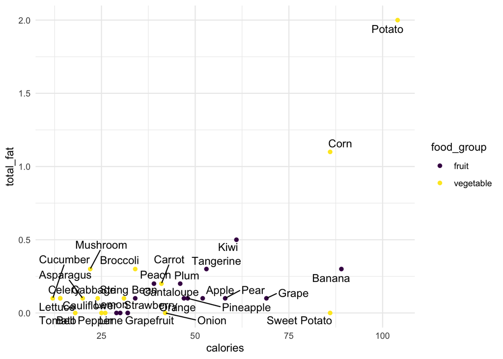

```r
food |>
  filter(food_group %in% c("vegetable", "fruit")) |>
  filter(total_fat < 10) |>
  ggplot() +
    geom_point(aes(x = calories, y = total_fat, color = food_group)) +
    geom_text_repel(aes(x = calories, y = total_fat, label = item)) +
    scale_color_viridis_d()
```

The pattern of a starting with a data set, applying a number of transformations, and then creating a visualization of the data will become a common pattern in our analyses.

## Data and Layers

Now that we know how to create a subset of our data, let’s use this new knowledge to build some interesting data visualizations. To start, create a data set that just consists of the food types that are in the meat food group:

```r
food_meat <- filter(food, food_group %in% c("meat"))
food_meat
```

```
## # A tibble: 6 × 17
##   item  food_group calories total_fat sat_fat cholesterol sodium carbs fiber
##   <chr> <chr>         <dbl>     <dbl>   <dbl>       <dbl>  <dbl> <dbl> <dbl>
## 1 Beef  meat            288      19.5    7.73          87    384     0     0
## 2 Chic… meat            237      13.4    3.76          87    404     0     0
## 3 Duck  meat            132       5.9    2.32          77     74     0     0
## 4 Lamb  meat            292      20.7    8.76          96    394     0     0
## 5 Pork  meat            271      17      6.17          90    384     0     0
## 6 Turk… meat            187       7      2.00          77     69     0     0
## # ℹ 8 more variables: sugar <dbl>, protein <dbl>, iron <dbl>,
## #   vitamin_a <dbl>, vitamin_c <dbl>, wiki <chr>, description <chr>,
## #   color <chr>
```

One of the core ideas behind the Grammar of Graphics is that complex visualizations can be constructed by layering relatively simply elements on top of one another. What if we wanted to put together two layers where one layer uses the `food` data set and the other uses `food_meat`? To do this, we can *override* the default data set in a layer with the option `data =`. This will use a different data set within a particular layer. For example, here is how we can layer the meat data set on top of the rest of the food items.

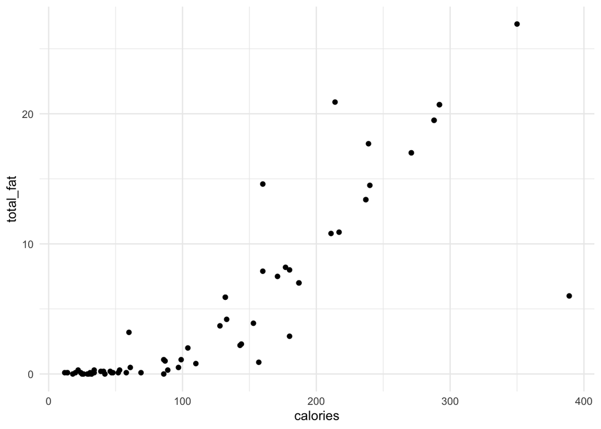

```r
food |>
  ggplot() +
    geom_point(aes(x = calories, y = total_fat)) +
    geom_point(aes(x = calories, y = total_fat), data = food_meat)
```

This plot, however, does not look any different than it would if we were just to plot all of the food together. The second layer of points just sits unassumingly on top of the rest of the data. To rectify this, we can color each layer a different color in order to distinguish them from one another. Let’s try to highlight the meat food group in a navy blue, while making the rest of the points a light grey:

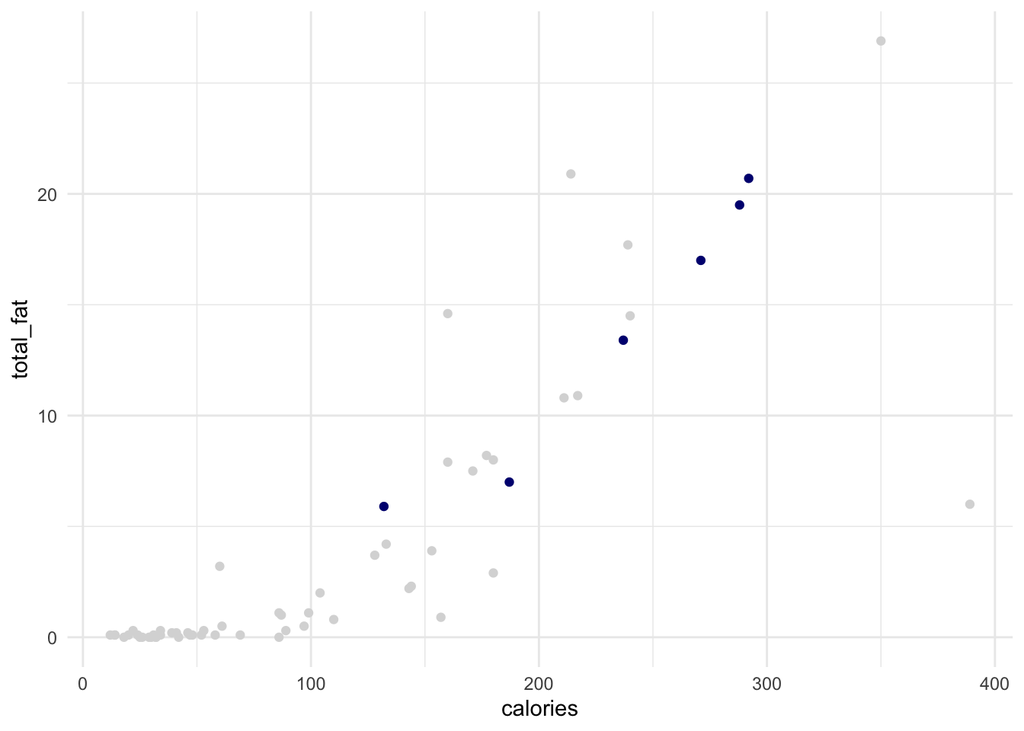

```r
food |>
  ggplot() +
    geom_point(aes(x = calories, y = total_fat), color = "grey85") +
    geom_point(aes(x = calories, y = total_fat), color = "navy", data = food_meat)
```

We now have a plot that shows exactly where the meats are relative to the other food items. We can further build up the plot by showing the names of just these rows of the dataset as well:

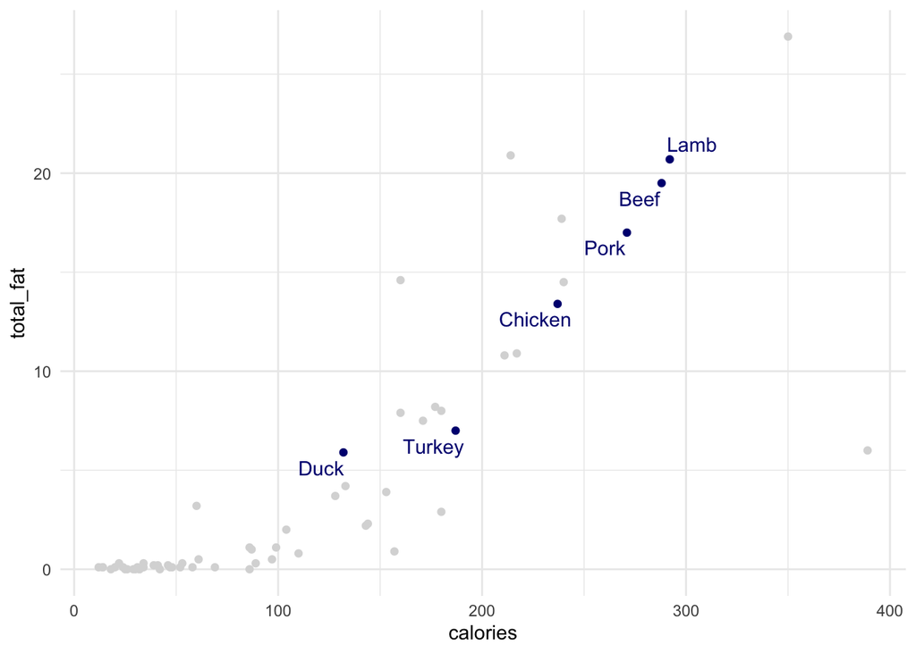

```r
food |>
  ggplot() +
    geom_point(aes(x = calories, y = total_fat), color = "grey85") +
    geom_point(aes(x = calories, y = total_fat), color = "navy", data = food_meat) +
    geom_text_repel(
      aes(x = calories, y = total_fat, label = item),
      color = "navy",
      data = food_meat
    )
```

Notice that the code is starting to get a bit more complicated and some of the graphic layers are becoming a bit long. This is a good place to use the shorthand notation to inherit aesthetics across layers, like this:

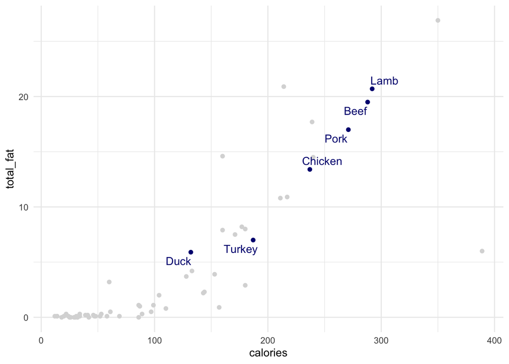

```r
food |>
  ggplot(aes(calories, total_fat)) +
    geom_point(color = "grey85") +
    geom_point(color = "navy", data = food_meat) +
    geom_text_repel(aes(label = item), color = "navy", data = food_meat)
```

Notice how a relatively small set of commands can be put together in different ways to build a variety of plots. Already, we are making further progress towards building informative and beautiful graphics in R!

## Selecting Columns

It is also possible to take a subset of the columns in a data set. To do this, we make use of the verb `select`. We pass it the names of the features we want to keep in the output data set, in the (possibly new) order that we want the columns to be arranged in. Here, for example, is a new version of the foods data set containing only the food item name followed by the amount of Vitamin A and Vitamin C:

```r
food |>
  select(item, vitamin_a, vitamin_c)
```

```
## # A tibble: 61 × 3
##    item        vitamin_a vitamin_c
##    <chr>           <dbl>     <dbl>
##  1 Apple               1         8
##  2 Asparagus          15         9
##  3 Avocado             3        17
##  4 Banana              1        15
##  5 Chickpea            0         3
##  6 String Bean        14        27
##  7 Beef                0         0
##  8 Bell Pepper        63       317
##  9 Crab                0         5
## 10 Broccoli           12       149
## # ℹ 51 more rows
```

## Arranging Rows

The verbs `slice` and `filter` determine a subset of rows to keep from the original data set. The `arrange` verb, in contrast, keeps all of the original data but re-orders its rows. Specifically, we give it one or more feature names and it sorts the data by the first feature from smallest to largest (or alphabetically for character feature). In the case of ties, the second feature is used if given. More features can be given to further break additional ties. Here is an example where we order the data set first by `food_group` and then by `calories`:

```r
food |>
  arrange(food_group, calories)
```

```
## # A tibble: 61 × 17
##    item       food_group calories total_fat sat_fat cholesterol sodium carbs
##    <chr>      <chr>         <dbl>     <dbl>   <dbl>       <dbl>  <dbl> <dbl>
##  1 Milk       dairy            60       3.2   1.86           10     40  4.52
##  2 Yogurt     dairy            99       1.1   0.742           5     53 18.6
##  3 Sour Cream dairy           214      20.9  13.0            44     53  4.27
##  4 Cheese     dairy           350      26.9  16.6            83    955  4.71
##  5 Crab       fish             87       1     0.222          78    293  0.04
##  6 Lobster    fish             97       0.5   0.106          71    700  1.27
##  7 Haddock    fish            128       3.7   0.69           66    402  0.48
##  8 Flounder   fish            133       4.2   0.867          56    417  0.41
##  9 Shrimp     fish            144       2.3   0.446         206    613  1.24
## 10 Tuna       fish            153       3.9   0.811          53    366  0.41
## # ℹ 51 more rows
## # ℹ 9 more variables: fiber <dbl>, sugar <dbl>, protein <dbl>, iron <dbl>,
## #   vitamin_a <dbl>, vitamin_c <dbl>, wiki <chr>, description <chr>,
## #   color <chr>
```

In the new data set all of the dairy products come up first followed by the fish products. Within each group, the items are sorted from the lowest to highest number of calories.

The ordering can be reversed (i.e., from the highest to the lowest value) be wrapping a feature name in the function `desc()`, such as this ordering from the most saturated fat to the least:

```r
food |>
  arrange(desc(sat_fat))
```

```
## # A tibble: 61 × 17
##    item       food_group calories total_fat sat_fat cholesterol sodium carbs
##    <chr>      <chr>         <dbl>     <dbl>   <dbl>       <dbl>  <dbl> <dbl>
##  1 Cheese     dairy           350      26.9   16.6           83    955  4.71
##  2 Sour Cream dairy           214      20.9   13.0           44     53  4.27
##  3 Lamb       meat            292      20.7    8.76          96    394  0
##  4 Beef       meat            288      19.5    7.73          87    384  0
##  5 Pork       meat            271      17      6.17          90    384  0
##  6 Chicken    meat            237      13.4    3.76          87    404  0
##  7 Catfish    fish            240      14.5    3.25          69    398  8.54
##  8 Halibut    fish            239      17.7    3.10          59    103  0
##  9 Duck       meat            132       5.9    2.32          77     74  0
## 10 Cod        fish            211      10.8    2.22          57    401  8.25
## # ℹ 51 more rows
## # ℹ 9 more variables: fiber <dbl>, sugar <dbl>, protein <dbl>, iron <dbl>,
## #   vitamin_a <dbl>, vitamin_c <dbl>, wiki <chr>, description <chr>,
## #   color <chr>
```

In the result here, “Cheese” has been placed at the top of the data set, followed by “Sour Cream” and “Lamb”.

One particularly useful application of `arrange` is to pair it with the verb `slice`. Here, for example, is the code to select the six foods in our data set that have the highest amount of Vitamin A:

```r
food |>
  arrange(desc(vitamin_a)) |>
  slice(1:6)
```

```
## # A tibble: 6 × 17
##   item  food_group calories total_fat sat_fat cholesterol sodium carbs fiber
##   <chr> <chr>         <dbl>     <dbl>   <dbl>       <dbl>  <dbl> <dbl> <dbl>
## 1 Carr… vegetable        41       0.2   0.037           0     69  9.58   2.8
## 2 Swee… vegetable        86       0     0.018           0     55 20.1    3
## 3 Cant… fruit            34       0.1   0.051           0     16  8.16   0.9
## 4 Bell… vegetable        26       0     0.059           0      2  6.03   2
## 5 Grap… fruit            32       0     0.014           0      0  8.08   1.1
## 6 Toma… vegetable        18       0     0.046           0      5  3.92   1.2
## # ℹ 8 more variables: sugar <dbl>, protein <dbl>, iron <dbl>,
## #   vitamin_a <dbl>, vitamin_c <dbl>, wiki <chr>, description <chr>,
## #   color <chr>
```

By saving this data set, we could highlight these specific foods on top of a plot comparing them to the remainder of the data.

## Homework Questions

Consider the following subset of the `hans` dataset we worked with in the previous notebook:

```
## # A tibble: 7 × 4
##   country       continent life_exp    gdp
##   <chr>         <chr>        <dbl>  <dbl>
## 1 Canada        Americas      80.7 36319.
## 2 France        Europe        80.7 30470.
## 3 Ireland       Europe        78.9 40676.
## 4 Netherlands   Europe        79.8 36798.
## 5 Portugal      Europe        78.1 20510.
## 6 Spain         Europe        80.9 28821.
## 7 United States Americas      78.2 42952.
```

For each of the following five questions, write the R code that would produce the desired data set:

1. Filter to include only those countries that have a life expectancy above 80 years.
2. Order the data set from the highest life expectancy to the lowest life expectancy.
3. Select only those rows that are located in Europe.
4. Create a data set that only has all seven rows of the original data but includes only the features `country` and `gdp`.
5. Create a data set that takes only the first two rows of the starting data.